# Inbred-based populations (Backcrosses, F2s and RILs)

Starting in version 2.0-0, `OneMap` can also deal with inbred-based populations, i. e., populations that have homozygous parental lines in the genealogy (F2s, backcrosses and RILs). As a consequence, linkage phases do not need to be estimated.

In this vignette we explain how to proceed the analysis in an F2 population. The same procedure can be used for backcrosses and RILs as well, and therefore users should not have any difficulty on analyzing their data. However, there are a number of differences for genetic mapping for outcrossing species; please read the proper vignette.

If you are not familiar with `R`, we recommend first the reading of vignette [Introduction to R](http://htmlpreview.github.com/?https://github.com/augusto-garcia/onemap/blob/master/vignettes_html/Introduction_R.html). You do not need to be an expert in R to build your linkage map, but some concepts are necessary and will help you through the process.

## Creating the data file

For F2s, backcrosses and RILs, we use exactly the same raw file used by `MAPMAKER/EXP` (Lander et al., 1987). Therefore, one should have no difficult in using data sets already available for `MAPMAKER/EXP` if deciding to try `OneMap`.

This raw file can contain phenotypic information in the same way as a `MAPMAKER/EXP` file. However, this information will not be used during the map construction, that requires only genotypic information (made available by molecular markers).

This raw file, combined with the map file produced by `OneMap`, can be readily used for QTL mapping using `R/qtl` (Broman et al., 2008) or `QTL Cartographer` (Wang et al., 2010), among others.

Here, we briefly present how to set up this data file. For more detailed information see the `MAPMAKER/EXP` manual (Lincon et al., 1993), available [here](http://home.cc.umanitoba.ca/%7Epsgendb/birchhomedir/doc/mapmaker/mapmaker.tutorial.pdf).

The first line of your raw data file should be:

```
data type xxxx
```

where `xxxx` is one of the following data types:

| `xxxx` | Population type |
| --- | --- |
| `f2 backcross` | Backcross |
| `f2 intercross` | F2 |
| `ri self` | RIL, produced by selfing |
| `ri sib` | RIL, produced by sib mating |

The second line should contain the number of individuals in the progeny, the number of markers and the number of quantitative traits. So, for example, a valid line would be

```
10 5 2
```

for a data set with 10 individuals (yes, very small, but this is just an example), 5 markers and 2 traits evaluated.

Then, the file must have genotypic information for each marker. The character `*` indicates the beginning of information of a marker, followed by the marker name. For example, here is an example of such file for an F2 population with 10 individuals, 5 markers and 2 quantitative traits:

```
data type f2 intercross
10 5 2

*M1 A B H H A - B A A B
*M2 C - C C C - - C C A
*M3 D B D D - - B D D B
*M4 C C C - A C C A A C
*M5 C C C C C C C C C C

*weight 10.2 - 9.4 11.3 11.9 8.9 - 11.2 7.8 8.1
*length 1.7 2.1 - 1.8 2.0 1.0 - 1.7 1.0 1.1
```

The codification for genotypes is the following:

| Code | Meaning |
| --- | --- |
| `A` | homozygous for allele A (from parental 1 - AA) |
| `B` | homozygous for allele B (from parental 2 - BB) |
| `H` | heterozygous carrying both alleles (AB) |
| `C` | Not homozygous for allele A (Not AA) |
| `D` | Not homozygous for allele B (Not BB) |
| `-` | Missing data for the individual at this marker |

The `symbols` option (not included in this example), used in `MAPMAKER/EXP` files, is also accepted (please, see its manual for details).

The quantitative trait data should come after the genotypic data and has a similar format, except the trait values for each individual must be separate by at least one space, a tab or a line break. A dash (`-`) indicates missing data.

This file must be saved in plain text format using a simple text editor such as *notepad* on *Microsoft Windows*. Historically, `MAPMAKER/EXP` uses the `.raw` extension for this file; however, you can use any other extension, such as `.txt`.

If you want to see more examples about this file type, open `fake.bc.onemap.raw` and `fake.f2.onemap.raw`, both available with `OneMap` and saved in the directory `example` on your computer, in the folder where you installed `OneMap` (use `system.file(package="onemap")` to see where it is located on your computer).

Now, let us load `OneMap`:

```r
library(onemap)
```

To save your project anytime, type:

```r
save.image("C:/.../yourfile.RData")
```

if you are using Windows; otherwise, adapt the codes. Notice that you need to specify where to save and the name of the file. You can also use the toolbar, of course.

## Importing data

Once you created your data file with raw data, you can use `OneMap` function `read.mapmaker` to import it to `OneMap`:

```r
fake.f2.onemap <- read.mapmaker(dir="C:/workingdirectory",
                                file="your_data_file.raw")
```

The first argument is the directory where the input file is located, so modify it accordingly. The second one is the data file name.

In this example, an object named `fake.f2.onemap` was created. Notice that if you leave the argument `dir` blank, the file will be read from your *working directory*. To set a working directory, see [Introduction to R (Importing and Exporting Data)](http://htmlpreview.github.com/?https://github.com/augusto-garcia/onemap/blob/master/vignettes_html/Introduction_R.html).

For this example, we will use a simulated data set from an F2 population which is distributed along with `OneMap`. Since this particular data set is distributed along with the package, you can load it typing

```r
data(fake.f2.onemap)
```

To see what this data set is about, type

```r
fake.f2.onemap
```

```
## This is an object of class 'f2.onemap'
##     No. individuals:     200
##     No. markers:         66
##     Percent genotyped:   85
##
##     Number of markers per type:
##        AA : AB : BB -->  36
##         Not BB : BB -->  15
##         Not AA : AA -->  15
##
## This data contains phenotypic information
```

As you can see, the data consists in a sample of 200 individuals genotyped for 66 markers (36 co-dominant (`AA`, `AB` or `BB`), 15 dominant in one parent (`Not AA` or `AA`) and 15 dominant in the other parent (`Not BB` or `BB`) with 15% of missing data. You also can see that there is also phenotypic information on the data set, that can be used for QTL mapping.

## Visualization of raw data

Before building you linkage map, you should take a quick look on your data set. First, notice that by reading the raw data into `OneMap`, an object of class `f2.onemap` was produced:

```r
class(fake.f2.onemap)
```

```
## [1] "f2.onemap"
```

In fact, function `read.mapmaker` will produce objects of classes `bc.onemap`, `riself.onemap`, `risib.onemap` or `f2.onemap`, following the information in the data file for inbred-based populations. Therefore, you can use function `OneMap`'s version of function `plot` to produce a graphic with information about raw data. It will automatically recognize the class of the object and will produce the graphic. To see it in action, try:

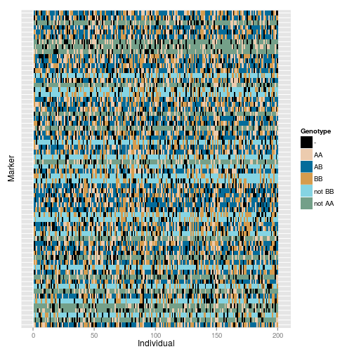

```r
plot(fake.f2.onemap)
```

The graphic is self-explanatory. If you want to save it, see the help for `plot.f2.onemap` function (if you have a different populations, try `plot.bc.onemap`, etc):

```r
?plot.f2.onemap
```

This graphic shows that missing data is somehow randomly distributed; also, the proportion of dominant markers is relatively high for this data set. In Onemap's notation, co-dominant markers are classified as of B type; dominant ones, by C type (for details about this notation, see the vignette for outcrossing species). You can see the number of loci within each type using funcion `plot.by.type`:

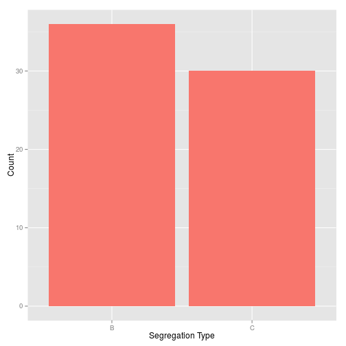

```r
plot.by.type(fake.f2.onemap)
```

So, as showed before, there is 36 co-dominant loci, and 30 dominant ones.

## Segregation tests

Now, it should be interesting to see if markers are segregating following what is expected by Mendel's law. You first need to use function `test.segregation` using as argument `OneMap` object of class `f2.onemap` (or `bc.onemap`, etc, for other population types).

```r
f2.test <- test.segregation(fake.f2.onemap)
```

This will produce an object of class `onemap.segreg.test`:

```r
class(f2.test)
```

```
## [1] "onemap.segreg.test"
```

You cannot see the results if you type the object name; use Onemap's version of `print` function for objects of classes `f2.onemap`, etc.

```r
f2.test
```

(Nothing is showed!)

```r
print(f2.test)
```

```
##    Marker    H0  Chi-square     p-value % genot.
## 1      M1 1:2:1 0.206896552 0.901722662     87.0
## 2      M2   3:1 0.292682927 0.588506355     82.0
## 3      M3   3:1 0.124031008 0.724703003     86.0
## 4      M4   3:1 0.292682927 0.588506355     82.0
## 5      M5   3:1 0.159763314 0.689374522     84.5
## 6      M6   3:1 0.620689655 0.430791121     87.0
## 7      M7 1:2:1 3.185185185 0.203397600     81.0
## 8      M8   3:1 0.165644172 0.684012345     81.5
## 9      M9   3:1 0.126984127 0.721579725     84.0
## 10    M10 1:2:1 1.721893491 0.422761645     84.5
## 11    M11   3:1 1.390946502 0.238245323     81.0
## 12    M12 1:2:1 1.678160920 0.432107681     87.0
## 13    M13   3:1 0.154285714 0.694472964     87.5
## 14    M14 1:2:1 5.337209302 0.069348924     86.0
```

[output cut: 52 more lines]

This shows the results of the Chi-square test for the expected Mendelian segregation pattern of each marker loci. This depends of course on marker type, since co-dominant markers can show heterozygous genotypes. The appropriate null hypothesis is selected by the function. The proportion of individuals genotyped is also showed.

To declare statistical significance, remember that you should consider that multiple tests are being performed. To guide you in the analysis, function `Bonferroni.alpha` shows the alpha value that should be considered for this number of loci if applying Bonferroni's correction with global alpha of 0.05:

```r
Bonferroni.alpha(f2.test)
```

```
## [1] 0.0007575758
```

You can subset object `f2.test` to see which markers are distorted under Bonferroni's argument, but it is easier to see the proportion of markers that are distorted by drawing a graphic using OneMap's version of the function `plot` for objects of class `onemap.segreg.test`:

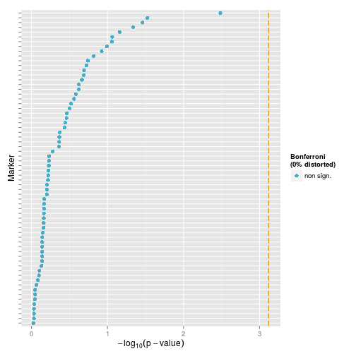

```r
plot(f2.test)
```

Graphic is self-explanatory: p-values were transformed by using -log10(p-values) for better visualization. A vertical line shows the threshold for tests if Bonferroni's correction is applied. Significant and non-significant tests are identified. In this particular example, no one was statistically significant, and so will not be discard.

Please, remember that Bonferroni's correction is **conservative**, and also that discarding marker data could not be a good approach to your analysis. This graphic is just to suggest a criteria, so use it with carefully.

You can see a list of markers with non-distorted segregation using function `subset.chisq`:

```r
(non.dist <- subset.chisq(f2.test))
```

```
##  [1] "M1"  "M2"  "M3"  "M4"  "M5"  "M6"  "M7"  "M8"  "M9"  "M10" "M11"
## [12] "M12" "M13" "M14" "M15" "M16" "M17" "M18" "M19" "M20" "M21" "M22"
## [23] "M23" "M24" "M25" "M26" "M27" "M28" "M29" "M30" "M31" "M32" "M33"
## [34] "M34" "M35" "M36" "M37" "M38" "M39" "M40" "M41" "M42" "M43" "M44"
## [45] "M45" "M46" "M47" "M48" "M49" "M50" "M51" "M52" "M53" "M54" "M55"
## [56] "M56" "M57" "M58" "M59" "M60" "M61" "M62" "M63" "M64" "M65" "M66"
```

For having a list of distorted ones (none in this example):

```r
(distorted <- subset.chisq(f2.test, distorted=TRUE))
```

```
## character(0)
```

This can be used in other steps of the analysis, as will be show.

## Estimating two-point recombination fractions

After evaluating raw data and checking for segregation distortion, let us now estimate recombination fractions between all pairs of markers (two-point tests). This is necessary to allows us to tests which markers are linked. At this point, you should pay no attention if markers have segregation distortion or not, i. e., simply use all of them.

```r
twopts.f2 <- rf.2pts(fake.f2.onemap)
```

There are two optional arguments in function `rf.2pts`: `LOD` and `max.rf` which indicate the minimum LOD Score and the maximum recombination fraction to declare linkage (defaults to 3.0 and 0.5).

The default for the recombination fraction is easy to understand, since if `max.rf<0.5` we could state that markers are linked. The LOD Score is the statistic used to evaluate the significance of the test for `max.rf=0.50`. This needs to take into consideration the number of tests performed, that of course depends on the number of markers. Function `suggest.lod` can help users to find an initial value to use for their linkage test. For this example:

```r
suggest.lod(fake.f2.onemap)
```

```
## [1] 3.887385
```

So, one should consider using `LOD=4` for the tests. Please, notice that this is just a guide, not a value to take without any further consideration. For now, we will keep the default values, but later will show that results will not change in our example by using `LOD=3` or `LOD=4`.

If you want to see the results for a single pair of markers, say `M12` and `M42`, use:

```r
print(twopts.f2, "M12", "M42")
```

```
##   Results of the 2-point analysis for markers: M12 and M42
##   Criteria: LOD =  3 , Maximum recombination fraction =  0.5
##
##        rf       LOD
## 0.3572168 1.9430819
```

```r
class(twopts.f2)
```

```
## [1] "rf.2pts"
```

However, objects of this type are too complex to print if you do not specify a pair of markers:

```r
print(twopts.f2)
```

```
##   This is an object of class 'rf.2pts'
##
##   Criteria: LOD = 3 , Maximum recombination fraction = 0.5
##
##   This object is too complex to print
##   Type 'print(object,mrk1=marker,mrk2=marker)' to see the analysis for two markers
##     mrk1 and mrk2 can be the names or numbers of both markers
```

## Assigning markers to linkage groups

### Defining a sequence of markers

To assign markers to linkage groups, first use the function `make.seq` to create a (un-ordered) sequence with all markers:

```r
mark.all.f2 <- make.seq(twopts.f2, "all")
```

Function `make.seq` is used to create sequences from objects of several different classes. Here, the first argument is of class `rf.2pts` and the second argument specifies which markers one wants to use (`"all"` indicates that all markers will be analyzed). The object `mark.all.f2` has class `sequence`:

```r
class(mark.all.f2)
```

```
## [1] "sequence"
```

If you want to form groups with a subset of markers, say `M1`, `M3` and `M7`, use:

```r
mrk.subset<-make.seq(twopts.f2, c(1,3,7))
```

In this case, it was easy because marker names and order in the objects (indicated in vector `c(1,3,7)`) are closed related, i. e., you can easily know the position of markers in the object once you know its name. However, this is not true for real data sets, where markers do not have simple names such as `M1` or `M2`.

A good example is to use the vector of markers without segregation distortion that we selected when applying the Chi-square tests.

(To be included)

### Forming the groups

You can assign markers to linkage groups using the function `group`:

```r
LGs.f2 <- group(mark.all.f2)
LGs.f2
```

```
##   This is an object of class 'group'
##   It was generated from the object "mark.all.f2"
##
##   Criteria used to assign markers to groups:
##     LOD = 3 , Maximum recombination fraction = 0.5
##
##   No. markers:            66
##   No. groups:             3
##   No. linked markers:     66
##   No. unlinked markers:   0
##
##   Printing groups:
##   Group 1 : 27 markers
##     M1 M3 M4 M6 M7 M9 M12 M13 M17 M23 M26 M27 M29 M30 M31 M34 M35 M36 M40 M42 M44 M46 M53 M55 M58 M60 M63
##
##   Group 2 : 16 markers
##     M2 M5 M8 M10 M11 M25 M32 M33 M37 M41 M43 M45 M51 M54 M61 M66
##
##   Group 3 : 23 markers
##     M14 M15 M16 M18 M19 M20 M21 M22 M24 M28 M38 M39 M47 M48 M49 M50 M52 M56 M57 M59 M62 M64 M65
```

This will show the linkage groups that will be formed if criteria defined by `max.rf` and `LOD` is applied to define thresholds to be used when assigning markers to linkage groups. If not modified, the same values used for the object `twopts` (from two-point analysis) will be maintained (so, `LOD=3.0` and `max.rf=0.5` in this example).

Users can easily change the default values. For example, using LOD suggested by `suggest.lod` (rounded up):

```r
(LGs.f2 <- group(mark.all.f2, LOD=4, max.rf=0.5))
```

```
##   This is an object of class 'group'
##   It was generated from the object "mark.all.f2"
##
##   Criteria used to assign markers to groups:
##     LOD = 4 , Maximum recombination fraction = 0.5
##
##   No. markers:            66
##   No. groups:             3
##   No. linked markers:     66
##   No. unlinked markers:   0
##
##   Printing groups:
##   Group 1 : 27 markers
##     M1 M3 M4 M6 M7 M9 M12 M13 M17 M23 M26 M27 M29 M30 M31 M34 M35 M36 M40 M42 M44 M46 M53 M55 M58 M60 M63
##
##   Group 2 : 16 markers
##     M2 M5 M8 M10 M11 M25 M32 M33 M37 M41 M43 M45 M51 M54 M61 M66
##
##   Group 3 : 23 markers
##     M14 M15 M16 M18 M19 M20 M21 M22 M24 M28 M38 M39 M47 M48 M49 M50 M52 M56 M57 M59 M62 M64 M65
```

No difference was obtained in this example. (The parenthesis above is just to avoiding type the object `LGs.f2` in another row to have it printed).

We can see that the markers were assigned to three linkage groups with 27, 16 and 23 markers; no markers were kept un-linked.

Notice the class of object `LGs.f2`:

```r
class(LGs.f2)
```

```
## [1] "group"
```

## Ordering markers within linkage groups

After the assignment of markers to linkage groups, the next step is to order the markers within each group.

First, let us choose the mapping function used to display the genetic map. We can choose between Kosambi or Haldane mapping functions. To use Haldane, type

```r
set.map.fun(type="haldane")
```

To use Kosambi's function:

```r
set.map.fun(type="kosambi")
```

### Linkage group 2

We will start our analysis using the smallest linkage group (group 2). To do so, you must `extract` it from the object of class `group`. Let us extract the group 2 using function `make.seq`:

```r
LG2.f2 <- make.seq(LGs.f2, 2)
```

The first argument is an object of class `group` and the second is a number indicating which linkage group will be extracted. In this case, the object `LGs.f2`, generated by function `group`, is of class `group`. In fact, this function can handle different classes of objects.

If you type

```r
LG2.f2
```

```
##
## Number of markers: 16
## Markers in the sequence:
## M2 M5 M8 M10 M11 M25 M32 M33 M37 M41 M43 M45 M51 M54 M61 M66
##
## Parameters not estimated.
```

you will see which markers are comprised in the sequence. But notice that no parameters have been estimated so far (the function says *Parameters not estimated*). This refers to the fact that so far we only attributed markers to linkage groups, but we did not perform any analysis for them as a **group**, but only as pairs. (It seems complicated? Do not worry, you will understand details in a moment).

Notice the class of object `LG2.f2`:

```r
class(LG2.f2)
```

```
## [1] "sequence"
```

To order markers in this group, you can use a two-point based algorithm such as Seriation (Buetow and Chakravarti, 1987), Rapid Chain Delineation (Doerge, 1996), Recombination Counting and Ordering (Van Os et al., 2005) and Unidirectional Growth (Tan and Fu, 2006):

```r
LG2.ser.f2 <- seriation(LG2.f2)
LG2.rcd.f2 <- rcd(LG2.f2)
LG2.rec.f2 <- record(LG2.f2)
LG2.ug.f2 <- ug(LG2.f2)
```

For this particular data set, the algorithms provided different results (results not printed in this vignette). For an evaluation and comparison of these methods, see Mollinari et al. (2009).

When possible (i. e., when groups have a small number of markers, in general up to 10 or 11), one should select the best order by comparing the multipoint likelihood of all possible orders between markers (exhaustive search). This procedure is implemented in the function `compare`. Although feasible for up to 10 or 11 markers, with 7 or more markers it will take a couple of hours until you see the results (depending of course on the computational resources available).

Linkage group 2 has 16 markers so the usage of function `compare` is unfeasible. Thus we will apply an heuristic that shows reliable results. First, we will choose a moderate number of markers, say 6, to create a framework using the function `compare`, and then we will positioning the remaining markers into this framework using function `try.seq`. The way we choose these markers in inbred-based populations is somewhat different from what we did in outcrossing populations, where there is a mixture of segregation patterns (see the vignette for details).

In our scenario, we recommend two methods:

1. Randomly choose a number of markers and calculate the multipoint likelihood of all possible orders (using the function `compare`). If the LOD Score of the second best order is greater than a threshold of, say, 3, then take the best order to proceed with the next step. If not, repeat the procedure.
2. Use some two-point based algorithm to construct a map; then, take equally spaced markers from this map. Then, create a framework of ordered markers using the function `compare`. Next, try to map the remaining markers, one at a time, beginning with co-dominants (most informative ones), then add the dominants.

You can do this procedure manually, in a similar way as done for outcrossing species (see the vignette for details). However, this procedure is automated in function `order.seq`, which we will use here:

```r
LG2.f2.ord <- order.seq(input.seq=LG2.f2, n.init = 5,
                        subset.search = "twopt",
                        twopt.alg = "rcd", THRES = 3,
                        draw.try = TRUE, wait = 1)
```

```
##
## Cross type:  f2
## Choosing initial subset using 'two-point' approach
##
## order obtained using RCD algorithm:
##
##  41 10 43 11 2 32 45 54 66 61 25 5 51 33 37 8
##
## calculating multipoint map using tol =  0.1 .
##
##
## Comparing 60 orders:
##
##
##
##
##
## Running try algorithm
## 66 --> M66 : ......
## 37 --> M37 : .......
## 61 --> M61 : ........
## 10 --> M10 : ........
## 33 --> M33 : .........
## 25 --> M25 : ..........
## 43 --> M43 : ...........
## 32 --> M32 : ............
## 51 --> M51 : .............
## 45 --> M45 : ..............
## 11 --> M11 : ..............
##
## LOD threshold = 3
##
## Positioned markers: 41 10 2 43 32 54 66 25 5 51 33 37 8
##
## Markers not placed on the map: 11 45 61
##
##
## Calculating LOD-Scores
## 11 --> M11 : ..............
## 45 --> M45 : ..............
## 61 --> M61 : ..............
##
##
## Placing remaining marker(s) at most likely position
## 61 --> M61 : ..............
## 45 --> M45 : ...............
## 11 --> M11 : ................
##
## Estimating final genetic map using tol = 10E-5.
```

(Results of the animation not shown in this vignette, for obvious reasons).

The first argument is an object of class `sequence` (LG2.f2).

```
n.init
= 5
```

means that five markers will be used in the `compare` step. The argument `subset.search = "twopt"` indicates that these five markers should be chosen by using a two point method, which will be Rapid Chain Delineation, as indicated by the argument `twopt.alg = "rcd"`. `THRES = 3` indicates that the `try.seq` step will only add markers to the sequence which can be mapped with LOD Score greater than 3. `draw.try=TRUE` will display a diagnostic graphic for each `try.seq` step. Finally, `wait=1` indicates the minimum time interval in seconds to display the diagnostic graphic, so you will some sort of “animation”.

**NOTE**: Although automation is very useful, this function and procedure can be misleading, specially if there are a considerable amount of missing data and dominant markers. So, use it carefully.

Check the order obtained by this procedure:

```r
LG2.f2.ord
```

```
##
## Best sequence found.
## Printing map:
##
## Markers           Position
##
## 41 M41                0.00
## 10 M10                8.66
##  2 M2                16.88
## 43 M43               22.27
## 32 M32               25.78
## 54 M54               33.28
## 66 M66               40.00
## 25 M25               47.16
##  5 M5                51.31
## 51 M51               55.64
## 33 M33               61.27
## 37 M37               65.59
##  8 M8                71.47
##
##  13 markers            log-likelihood: -942.9539
##
##
##
## The following markers could not be uniquely positioned.
## Printing most likely positions for each unpositioned marker:
##
## ------------------------
## |    |  11 |  45 |  61 |
## |----|-----|-----|-----|
## |    |     |     |     |
## | 41 |     |     |     |
## |    |     |     |     |
## | 10 |     |     |     |
## |    | **  |     |     |
## |  2 |     |     |     |
## |    | *** |     |     |
## | 43 |     |     |     |
## |    |     | *   |     |
## | 32 |     |     |     |
```

[output cut: 9 more lines]

```
## | 51 |     |     |     |
## |    |     |     |     |
## | 33 |     |     |     |
## |    |     |     |     |
## | 37 |     |     |     |
## |    |     |     |     |
## |  8 |     |     |     |
## |    |     |     |     |
## ------------------------
##
## '***' indicates the most likely position(s) (LOD = 0.0)
##
## '**' indicates very likely positions (LOD > -1.0)
##
## '*' indicates likely positions (LOD > -2.0)
```

To get the `safe` order, use

```r
LG2.f2.safe <- make.seq(LG2.f2.ord,"safe")
```

and to get the order with all markers (i.e. including the ones not mapped to a single position), use:

```r
(LG2.f2.all <- make.seq(LG2.f2.ord,"force"))
```

```
##
## Printing map:
##
## Markers           Position
##
## 41 M41                0.00
## 10 M10                8.53
##  2 M2                16.60
## 11 M11               19.27
## 43 M43               22.56
## 32 M32               26.34
## 45 M45               32.28
## 54 M54               34.59
## 66 M66               41.60
## 61 M61               43.27
## 25 M25               48.97
##  5 M5                53.02
## 51 M51               57.37
## 33 M33               63.00
## 37 M37               67.32
##  8 M8                73.21
##
##  16 markers            log-likelihood: -997.5836
```

which places markers `11` and `45` into their most likely positions (between markers `2` and `43` and `32` and `54`, respectively).

Although some old publications presented maps with only `safe` orders, we see no reason do not use option `force`, and recommend it for users.

The `order.seq` function can perform two rounds of the `try.seq` step, first using `THRES` and then `THRES - 1` as the threshold. This generally results in safe orders with more markers mapped, but takes longer to run. To do this, type:

```r
LG2.f2.ord <- order.seq(input.seq=LG2.f2, n.init = 5,
                        subset.search = "twopt",
                        twopt.alg = "rcd", THRES = 3,
                        draw.try = TRUE, wait = 1,
                        touchdown=TRUE)
```

```
##
## Cross type:  f2
## Choosing initial subset using 'two-point' approach
##
## order obtained using RCD algorithm:
##
##  41 10 43 11 2 32 45 54 66 61 25 5 51 33 37 8
##
## calculating multipoint map using tol =  0.1 .
##
##
## Comparing 60 orders:
##
##
##
##
##
## Running try algorithm
## 66 --> M66 : ......
## 37 --> M37 : .......
## 61 --> M61 : ........
## 10 --> M10 : ........
## 33 --> M33 : .........
## 25 --> M25 : ..........
## 43 --> M43 : ...........
## 32 --> M32 : ............
## 51 --> M51 : .............
## 45 --> M45 : ..............
## 11 --> M11 : ..............
##
## LOD threshold = 3
##
## Positioned markers: 41 10 2 43 32 54 66 25 5 51 33 37 8
##
## Markers not placed on the map: 11 45 61
##
##
##
## Trying to map remaining markers with LOD threshold  2
## 11 --> M11 : ..............
## 45 --> M45 : ..............
## 61 --> M61 : ..............
##
## LOD threshold = 2
##
## Positioned markers: 41 10 2 43 32 54 66 61 25 5 51 33 37 8
##
## Markers not placed on the map: 11 45
##
##
## Calculating LOD-Scores
## 11 --> M11 : ...............
## 45 --> M45 : ...............
##
##
## Placing remaining marker(s) at most likely position
## 45 --> M45 : ...............
## 11 --> M11 : ................
##
## Estimating final genetic map using tol = 10E-5.
```

```r
(LG2.f2.final<-make.seq(LG2.f2.ord, "force"))
```

```
##
## Printing map:
##
## Markers           Position
##
## 41 M41                0.00
## 10 M10                8.53
##  2 M2                16.60
## 11 M11               19.27
## 43 M43               22.56
## 32 M32               26.34
## 45 M45               32.28
## 54 M54               34.59
## 66 M66               41.60
## 61 M61               43.27
## 25 M25               48.97
##  5 M5                53.02
## 51 M51               57.37
## 33 M33               63.00
## 37 M37               67.32
##  8 M8                73.21
##
##  16 markers            log-likelihood: -997.5836
```

Finally, to check for alternative orders, use `ripple.seq` function:

```r
ripple.seq(LG2.f2.final, ws=5, LOD=3)
```

The second argument, `ws = 5`, means that subsets (windows) of five markers will be permutated sequentially (5! orders for each window), to search for other plausible orders. The `LOD` argument means that only orders with LOD Score smaller than 3 will be printed.

The final estimated map can then be printed using

```r
LG2.f2.final
```

```
##
## Printing map:
##
## Markers           Position
##
## 41 M41                0.00
## 10 M10                8.53
##  2 M2                16.60
## 11 M11               19.27
## 43 M43               22.56
## 32 M32               26.34
## 45 M45               32.28
## 54 M54               34.59
## 66 M66               41.60
## 61 M61               43.27
## 25 M25               48.97
##  5 M5                53.02
## 51 M51               57.37
## 33 M33               63.00
## 37 M37               67.32
##  8 M8                73.21
##
##  16 markers            log-likelihood: -997.5836
```

This will be based on multipoint estimation of recombination fractions, using hidden Markov models.

### Linkage group 1

Let us analyze linkage group 1. Extract markers from object `LGs`:

```r
LG1.f2 <- make.seq(LGs.f2, 1)
```

Construct the linkage map, by automatic usage of `try` algorithm:

```r
LG1.f2.ord <- order.seq(input.seq=LG1.f2, n.init = 5,
                        subset.search = "twopt",
                        twopt.alg = "rcd", THRES = 3,
                        draw.try = FALSE, wait = 1,
                        touchdown=TRUE)
```

```
##
## Cross type:  f2
## Choosing initial subset using 'two-point' approach
##
## order obtained using RCD algorithm:
##
##  3 4 55 27 9 42 53 46 1 30 7 6 35 13 58 34 63 26 40 36 44 29 60 23 31 17 12
##
## calculating multipoint map using tol =  0.1 .
##
##
## Comparing 60 orders:
##
##
##
##
##
## Running try algorithm
## 26 --> M26 : ......
##  1 --> M1  : .......
## 55 --> M55 : ........
## 40 --> M40 : .........
## 44 --> M44 : ..........
## 63 --> M63 : ..........
## 30 --> M30 : ...........
## 29 --> M29 : ............
## 27 --> M27 : .............
##  7 --> M7  : ..............
## 17 --> M17 : ...............
## 35 --> M35 : ................
## 58 --> M58 : ................
## 53 --> M53 : ................
##  6 --> M6  : .................
## 42 --> M42 : ..................
## 34 --> M34 : ..................
## 31 --> M31 : ..................
##  9 --> M9  : ...................
## 23 --> M23 : ...................
## 60 --> M60 : ....................
##  4 --> M4  : ....................
```

[output cut: 27 more lines]

```
##  4 --> M4  : .......................
## 34 --> M34 : .......................
## 35 --> M35 : .......................
## 42 --> M42 : .......................
## 60 --> M60 : .......................
##
##
## Placing remaining marker(s) at most likely position
## 60 --> M60 : .......................
## 35 --> M35 : ........................
##  4 --> M4  : .........................
## 42 --> M42 : ..........................
## 34 --> M34 : ...........................
##
## Estimating final genetic map using tol = 10E-5.
```

We use here option `draw.try=FALSE` just to shortening the vignette, but recommend that you change it for `TRUE`.

Get the order with all markers:

```r
(LG1.f2.final <- make.seq(LG1.f2.ord,"force"))
```

```
##
## Printing map:
##
## Markers           Position
##
## 55 M55                0.00
## 27 M27                7.69
##  9 M9                10.16
##  3 M3                21.28
##  4 M4                23.59
## 42 M42               30.04
## 53 M53               31.59
## 46 M46               35.89
##  1 M1                44.82
## 30 M30               48.87
```

[output cut: 19 more lines]

Check the final map (results not shown):

```r
ripple.seq(ws=5, LG1.f2.final)
```

No alternative order was found (please, try it).

Print it:

```r
LG1.f2.final
```

```
##
## Printing map:
##
## Markers           Position
##
## 55 M55                0.00
## 27 M27                7.69
##  9 M9                10.16
##  3 M3                21.28
##  4 M4                23.59
## 42 M42               30.04
## 53 M53               31.59
## 46 M46               35.89
##  1 M1                44.82
## 30 M30               48.87
```

[output cut: 19 more lines]

So, this is the final version of the map for this linkage group.

### Linkage group 3

Extract markers from object `LGs.f2`:

```r
LG3.f2 <- make.seq(LGs.f2, 3)
```

Construct the linkage map, by automatic usage of try algorithm and drawing some useful graphics (not shown; please change `draw.try` to `TRUE`):

```r
LG3.f2.ord <- order.seq(input.seq=LG3.f2, n.init = 5,
                        subset.search = "twopt",
                        twopt.alg = "rcd", THRES = 3,
                        draw.try = FALSE, wait = 1,
                        touchdown=TRUE)
```

```
##
## Cross type:  f2
## Choosing initial subset using 'two-point' approach
##
## order obtained using RCD algorithm:
##
##  47 19 39 38 49 59 28 14 16 65 62 15 21 24 64 20 52 48 57 22 18 56 50
##
## calculating multipoint map using tol =  0.1 .
##
##
## Comparing 60 orders:
##
##
##
##
##
## Running try algorithm
## 38 --> M38 : ......
## 56 --> M56 : .......
## 18 --> M18 : .......
## 22 --> M22 : ........
## 14 --> M14 : .........
## 28 --> M28 : ..........
## 57 --> M57 : ...........
## 62 --> M62 : ............
## 21 --> M21 : .............
## 65 --> M65 : ..............
## 16 --> M16 : ...............
## 52 --> M52 : ................
## 49 --> M49 : .................
## 24 --> M24 : .................
## 19 --> M19 : ..................
## 64 --> M64 : ...................
## 20 --> M20 : ...................
## 39 --> M39 : ....................
##
## LOD threshold = 3
##
## Positioned markers: 47 19 38 59 28 14 16 65 62 15 21 24 20 52 48 57 22 18 50
```

[output cut: 15 more lines]

```
## Markers not placed on the map: 39 49 64
##
##
## Calculating LOD-Scores
## 39 --> M39 : .....................
## 49 --> M49 : .....................
## 64 --> M64 : .....................
##
##
## Placing remaining marker(s) at most likely position
## 64 --> M64 : .....................
## 39 --> M39 : ......................
## 49 --> M49 : .......................
##
## Estimating final genetic map using tol = 10E-5.
```

We can see that in the second round of `try.seq` marker `M56` was added (please, try it). A careful examination of the graphics can be a good source of information about how markers where placed.

Now, get the order with all markers:

```r
(LG3.f2.final <- make.seq(LG3.f2.ord,"force"))
```

```
##
## Printing map:
##
## Markers           Position
##
## 47 M47                0.00
## 19 M19                7.56
## 39 M39                8.94
## 38 M38               15.77
## 49 M49               24.07
## 59 M59               24.50
## 28 M28               31.07
## 14 M14               35.46
## 16 M16               40.00
## 65 M65               45.54
## 62 M62               50.68
## 15 M15               54.67
## 21 M21               58.46
## 24 M24               61.83
## 20 M20               68.27
## 64 M64               68.27
## 52 M52               73.65
## 48 M48               79.05
## 57 M57               85.00
## 22 M22               88.25
## 18 M18               92.33
## 56 M56              102.05
## 50 M50              104.72
##
##  23 markers            log-likelihood: -1462.506
```

Check the final map (results not showed):

```r
ripple.seq(ws=5, LG3.f2.final)
```

No better alternative order was observed.

Print it:

```r
LG3.f2.final
```

```
##
## Printing map:
##
## Markers           Position
##
## 47 M47                0.00
## 19 M19                7.56
## 39 M39                8.94
## 38 M38               15.77
## 49 M49               24.07
## 59 M59               24.50
## 28 M28               31.07
## 14 M14               35.46
## 16 M16               40.00
## 65 M65               45.54
## 62 M62               50.68
## 15 M15               54.67
## 21 M21               58.46
## 24 M24               61.83
## 20 M20               68.27
## 64 M64               68.27
## 52 M52               73.65
## 48 M48               79.05
## 57 M57               85.00
## 22 M22               88.25
## 18 M18               92.33
## 56 M56              102.05
## 50 M50              104.72
##
##  23 markers            log-likelihood: -1462.506
```

## Map estimation for an arbitrary order

If you have some information about the order of the markers, for example, from a reference genome or previous published paper, you can define a sequence of those markers (using the function `make.seq`) and then use the function `map` to estimate the final genetic map (based on multipoint analysis). For example, let us assume that we know that the following markers are ordered in this sequence: `M47`, `M38`, `M59`, `M16`, `M62`, `M21`, `M20`, `M48` and `M22`. In this case, select them from the two point analysis, and use function `map`:

```r
LG3seq.f2 <- make.seq(twopts.f2,c(47,38,59,16,62,21,20,48,22))
(LG3seq.f2.map <- map(LG3seq.f2))
```

```
##
## Printing map:
##
## Markers           Position
##
## 47 M47                0.00
## 38 M38               14.49
## 59 M59               23.99
## 16 M16               40.13
## 62 M62               50.61
## 21 M21               57.84
## 20 M20               67.16
## 48 M48               75.76
## 22 M22               84.62
##
##  9 markers            log-likelihood: -947.1187
```

To see the correspondence between marker names and numbers, use function `marker.type`:

```r
marker.type(LG3seq.f2.map)
```

```
##   Marker 47 ( M47 ) --> AA : AB : BB (1:2:1)
##   Marker 38 ( M38 ) --> AA : AB : BB (1:2:1)
##   Marker 59 ( M59 ) --> Not  AA : AA (3:1)
##   Marker 16 ( M16 ) --> AA : AB : BB (1:2:1)
##   Marker 62 ( M62 ) --> AA : AB : BB (1:2:1)
##   Marker 21 ( M21 ) --> AA : AB : BB (1:2:1)
##   Marker 20 ( M20 ) --> Not  BB : BB (3:1)
##   Marker 48 ( M48 ) --> AA : AB : BB (1:2:1)
##   Marker 22 ( M22 ) --> AA : AB : BB (1:2:1)
```

If one needs to add or drop markers from a predefined sequence, functions `add.marker` and `drop.marker` can be used. For example, to add markers `M18`, `M56` and `50` in the end of `LG3seq.f2.map`:

```r
(LG3seq.f2.map <- add.marker(LG3seq.f2.map, c(18,56,50)))
```

```
##
## Number of markers: 12
## Markers in the sequence:
## M47 M38 M59 M16 M62 M21 M20 M48 M22 M18 M56 M50
##
## Parameters not estimated.
```

Removing markers `M59` and `21` from `LG3seq.f2.map`:

```r
(LG3seq.f2.map <- drop.marker(LG3seq.f2.map, c(59,21)))
```

```
##
## Number of markers: 10
## Markers in the sequence:
## M47 M38 M16 M62 M20 M48 M22 M18 M56 M50
##
## Parameters not estimated.
```

## Plotting the recombination fraction matrix

It is possible to plot the recombination fraction matrix and LOD Scores based on a color scale using the function `rf.graph.table`. This matrix can be useful to make some diagnostics about the map.

Just as an example, let us place `M38` in the end of linkage group 3 (wrong position) to see can we can see that in the graphic. First, let us to remove it from the linkage group:

```r
temp.seq<-drop.marker(LG3.f2.final, 38)
```

Now, we will force it to be positioned in the end of the linkage group:

```r
(temp.seq<-add.marker(temp.seq, 38))
```

```
##
## Number of markers: 23
## Markers in the sequence:
## M47 M19 M39 M49 M59 M28 M14 M16 M65 M62 M15 M21 M24 M20 M64 M52 M48 M57
## M22 M18 M56 M50 M38
##
## Parameters not estimated.
```

```r
(LG3.f2.wrong<-map(temp.seq))
```

```
##
## Printing map:
##
## Markers           Position
##
## 47 M47                0.00
## 19 M19                7.38
## 39 M39                9.16
## 49 M49               23.18
## 59 M59               24.38
## 28 M28               30.44
## 14 M14               34.82
## 16 M16               39.36
## 65 M65               44.90
## 62 M62               50.04
## 15 M15               54.03
## 21 M21               57.82
## 24 M24               61.19
## 20 M20               67.63
## 64 M64               67.63
## 52 M52               73.02
## 48 M48               78.41
## 57 M57               84.36
## 22 M22               87.61
## 18 M18               91.68
## 56 M56              101.39
## 50 M50              103.97
## 38 M38              160.29
##
##  23 markers            log-likelihood: -1589.563
```

Examining the results, we can see there is a big gap in the end of linkage group 3 (between markers `M50` and `M38`, as expected.

Now let us plot the recombination fraction matrix:

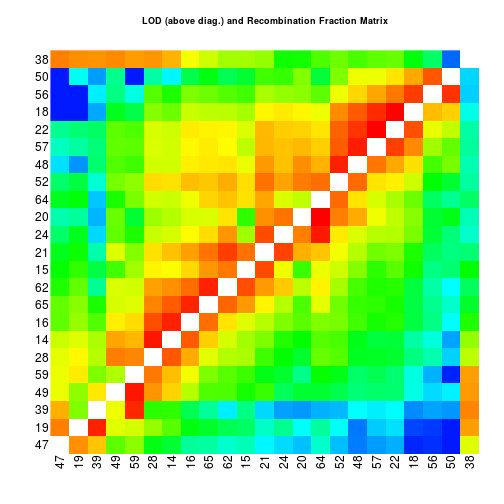

```r
rf.graph.table(LG3.f2.wrong, inter=FALSE)
```

The recombination fractions are plotted below the diagonal and the LOD Scores are plotted above the diagonal. The color scale varies from red (small distances big LODs) to dark blue.

You can also plot an interactive version of this graphic, changing option `inter` to `TRUE` (the default):

```r
rf.graph.table(LG3.f2.wrong)
```

An interactive version of the graphic will pop up (not showed here). Clicking on the cell corresponding to two markers, you can see some useful information about them. For example, clicking on the cell corresponding to markers `M47` and `M19` you can see their names, types (co-dominant and dominant), recombination fraction (

```
rf =
0.07323
```

) and LOD Score (`LOD = 23`). Clicking in a cell on the diagonal, some information about the corresponding marker is shown, including percentage of missing data. We found this to be very useful when evaluating the results of the ordering algorithms.

We clearly see a different pattern for marker `M38`. The blue cell, corresponding to markers `M50` and `M38`, indicates a big recombination fraction between these markers as seen before (by clicking, `rf = 0.4049`). Moreover, we can see a group of red cells corresponding to marker `M38` and markers `M59`, `M49`, `M39` and `M19`. This pattern indicates small recombination fractions between marker `M38` and other markers. Thus `M38` is suppose to be close to them on the map.

Since we have enough evidence that marker `M38` is misplaced, let us drop this marker and try to position it using the function `try.seq`:

```
## 38 --> M38 : .......................
```

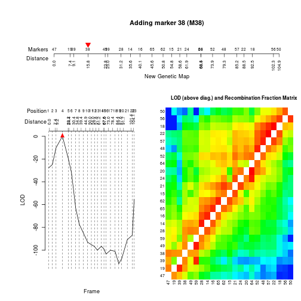

```r
temp.seq <- drop.marker(LG3.f2.wrong,38)
temp.map <- map(temp.seq)
temp.try <- try.seq(temp.map, 38, draw.try=TRUE)
```

We can see that the most likely position for marker `M38` is between markers `M39` and `M49` (position 4). The patterns on the color matrix show that now things are better. Therefore, you should do

```r
(LG3.f2.final<-make.seq(temp.try, 4))
```

```
##
## Printing map:
##
## Markers           Position
##
## 47 M47                0.00
## 19 M19                7.38
## 39 M39                9.14
## 38 M38               15.83
## 49 M49               23.84
## 59 M59               25.01
## 28 M28               31.17
## 14 M14               35.57
## 16 M16               40.10
## 65 M65               45.65
## 62 M62               50.78
## 15 M15               54.78
## 21 M21               58.57
## 24 M24               61.93
## 20 M20               68.37
## 64 M64               68.47
## 52 M52               73.86
## 48 M48               79.25
## 57 M57               85.21
## 22 M22               88.46
## 18 M18               92.53
## 56 M56              102.25
## 50 M50              104.93
##
##  23 markers            log-likelihood: -1462.577
```

## Drawing the genetic map

We can draw a genetic map for all linkage groups using the function `draw.map`. First we have to create a list of ordered linkage groups:

```r
maps.list<-list(LG1.f2.final, LG2.f2.final, LG3.f2.final)
```

Then use function `draw.map` for this list:

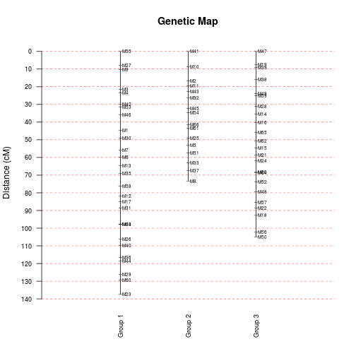

```r
draw.map(maps.list, names= TRUE, grid=TRUE, cex.mrk=0.7)
```

We also can draw a map for a specific linkage group:

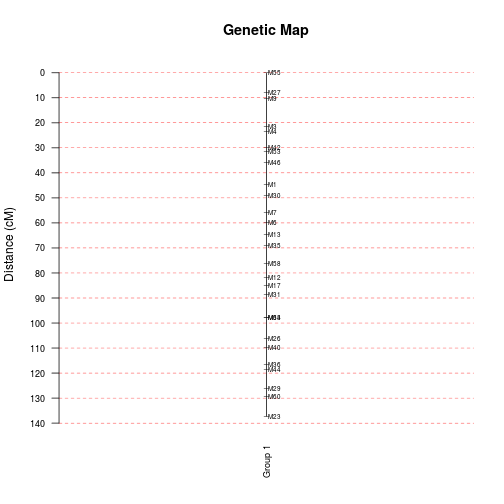

```r
draw.map(LG1.f2.final, names= TRUE, grid=TRUE, cex.mrk=0.7)
```

Function `draw.map` draws a very simple graphic representation of the genetic map. But, once the distances are estimated, better map figures can be drawn by the user using any appropriate software. There are several free softwares that can be used, such as [MapChart](https://www.wageningenur.nl/en/show/Mapchart.htm) (Voorrips, 2002).

## Exporting data to R/qtl and QTL Cartographer

Possibly one of the most important applications for a genetic map is its use in QTL mapping studies. In populations such as RILs, F2s and backcrosses, there are a lot of softwares for doing this analysis. Here, we illustrate how to export the genetic map from `OneMap` to the widely used and excellent packages [`R/qtl`](http://www.rqtl.org/) (Broman et al., 2008) and [`Windows QTL Cartographer`](http://statgen.ncsu.edu/qtlcart/WQTLCart.htm) (Wang et al., 2010).

Using the function `write.map`, let us export the list `maps.list`, defined in previous section, to a file named `fake.f2.onemap.map`:

```r
write.map(maps.list, "fake.f2.onemap.map")
```

Notice that the file will be written on the `working directory`, unless specified by the second argument.

Now, let us install the `R/qtl` package:

```r
install.packages("qtl")
```

Choose the nearest server location and proceed with the installation. Then, load `R/qtl`:

```r
library(qtl)
```

To read the data in `R/qtl` we will use the `MAPMAKER/EXP` format. Two files are needed: the first one is a file with information about the estimated map (`fake.f2.onemap.map` in our case); the second one is the raw file written in `MAPMAKER/EXP` style, which was used in the beginning of this example and has marker and phenotypic information for the QTL analysis. The simulated data `fake.f2.onemap` contains that information. The location of the raw file can be obtained using:

```r
raw.file<-paste(system.file("example",package="onemap"),
                "fake.f2.onemap.raw", sep="/")
```

Now we can read the data using the `R/qtl` function read.cross}:

```r
fake.f2.qtl <- read.cross("mm", file=raw.file, mapfile="fake.f2.onemap.map")
```

```
##  --Read the following data:
##  Type of cross:          f2
##  Number of individuals:  200
##  Number of markers:      66
##  Number of phenotypes:   1
##  --Cross type: f2
```

The first argument specifies the format of the data. In our case we used `mm` which stands for MAPMAKER. The second argument (`file`) indicates the raw file in `MAPMAKER/EXP` style and the third argument `mapfile` indicates the map file that was produced by `OneMap`.

Then we can proceed with the analysis. `R/qtl` has several function to check the map. For example, re-estimating the genetic map within `R/qtl`:

```r
newmap <- est.map(fake.f2.qtl, tol=1e-6, map.function="kosambi")
```

A comparison of the output of `R/qtl` and `OneMap` can be obtained with:

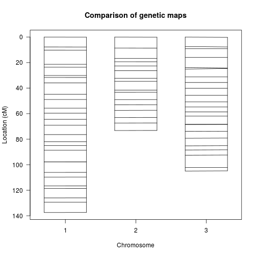

```r
plot.map(fake.f2.qtl, newmap)
```

For each one of the three chromosomes, the left vertical line represents the map estimated by `OneMap` and the right vertical line represents the map estimated by `R/qtl`. The lines linking these two maps indicates the position of the markers. Thus, we can see that the two maps are almost identical, with slightly differences in only one or two distances between markers.

Finally, we can run an interval mapping analysis for these data using the `R/qtl` function called `scanone` (for details, see [`R/qtl` Manual](http://cran.r-project.org/web/packages/qtl/qtl.pdf):

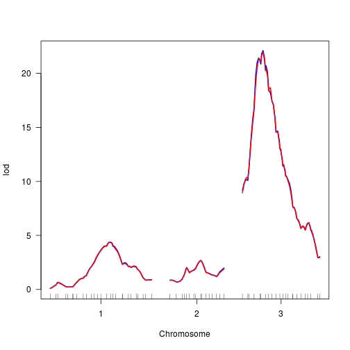

```r
fake.f2.qtl <- calc.genoprob(fake.f2.qtl, step=2)
out.em <- scanone(fake.f2.qtl, method="em")
out.hk <- scanone(fake.f2.qtl, method="hk")
plot(out.em, out.hk, col=c("blue","red"))
```

Here we performed an interval mapping using two methods: mixture models with EM algorithm and Haley-Knott regression. The blue lines indicate the first one and the red lines indicate the second.

We can use `R/qtl` to generate `QTL Cartographer` input files.

```r
write.cross(fake.f2.qtl, format="qtlcart", filestem="fake.f2.onemap")
```

Again, the file will be written in the *working directory*, unless you specify differently in argument `filestem`. The files produced this way are ready to be used in `Windows QTL Cartographer` for mapping QTL using a number of different models.

## Final remarks

At this point it should be clear that any potential `OneMap` user must have some knowledge about genetic mapping and also the R language, since the analysis is not done with *only one mouse click*. In the future, perhaps a graphical interface will be made available to make this software a lot easier to use.

We do hope that `OneMap` should be useful to any researcher interested in genetic mapping in outcrossing or inbred-based populations. Any suggestions and critics are welcome.

## References

Adler, J. *R in a Nutshell* A Desktop Quick Reference, 2009.

Broman, K. W., Wu, H., Churchill, G., Sen, S., Yandell, B. *qtl: Tools for analyzing QTL experiments* R package version 1.09-43, 2008. http://www.rqtl.org/

Buetow, K. H., Chakravarti, A. Multipoint gene mapping using seriation. I. General methods. *American Journal of Human Genetics* 41, 180-188, 1987.

Doerge, R.W. Constructing genetic maps by rapid chain delineation. *Journal of Agricultural Genomics* 2, 1996.

Garcia, A.A.F., Kido, E.A., Meza, A.N., Souza, H.M.B., Pinto, L.R., Pastina, M.M., Leite, C.S., Silva, J.A.G., Ulian, E.C., Figueira, A. and Souza, A.P. Development of an integrated genetic map of a sugarcane *Saccharum spp.* commercial cross, based on a maximum-likelihood approach for estimation of linkage and linkage phases. *Theoretical and Applied Genetics* 112, 298-314, 2006.

Haldane, J. B. S. The combination of linkage values and the calculation of distance between the loci of linked factors. *Journal of Genetics* 8, 299-309, 1919.

Jiang, C. and Zeng, Z.-B. Mapping quantitative trait loci with dominant and missing markers in various crosses from two inbred lines. *Genetica* 101, 47-58, 1997.

Kosambi, D. D. The estimation of map distance from recombination values. *Annuaire of Eugenetics* 12, 172-175, 1944.

Lander, E. S. and Green, P. Construction of multilocus genetic linkage maps in humans. *Proc. Natl. Acad. Sci. USA* 84, 2363-2367, 1987.

Lander, E.S., Green, P., Abrahanson, J., Barlow, A., Daly, M.J., Lincoln, S.E. and Newburg, L. MAPMAKER, An interactive computing package for constructing primary genetic linkage maps of experimental and natural populations. *Genomics* 1, 174-181, 1987.

Lincoln, S. E., Daly, M. J. and Lander, E. S. Constructing genetic linkage maps with MAPMAKER/EXP Version 3.0: a tutorial and reference manual. *A Whitehead Institute for Biomedical Research Technical Report* 1993.

Matloff, N. *The Art of R Programming*. 2011. 1st ed. San Francisco, CA: No Starch Press, Inc., 404 pages.

Margarido, G. R. A., Souza, A.P. and Garcia, A. A. F. OneMap: software for genetic mapping in outcrossing species. *Hereditas* 144, 78-79, 2007.

Mollinari, M., Margarido, G. R. A., Vencovsky, R. and Garcia, A. A. F. Evaluation of algorithms used to order markers on genetics maps. *Heredity* 103, 494-502, 2009.

Oliveira, K.M., Pinto, L.R., Marconi, T.G., Margarido, G.R.A., Pastina, M.M., Teixeira, L.H.M., Figueira, A.M., Ulian, E.C., Garcia, A.A.F., Souza, A.P. Functional genetic linkage map on EST-markers for a sugarcane (*Saccharum spp.*) commercial cross. *Molecular Breeding* 20, 189-208, 2007.

Oliveira, E. J., Vieira, M. L. C., Garcia, A. A. F., Munhoz, C. F.,Margarido, G. R.A., Consoli, L., Matta, F. P., Moraes, M. C., Zucchi, M. I., and Fungaro,M. H. P. An Integrated Molecular Map of Yellow Passion Fruit Based on Simultaneous Maximum-likelihood Estimation of Linkage and Linkage Phases *J. Amer. Soc. Hort. Sci.* 133, 35-41, 2008.

Tan, Y., Fu, Y. A novel method for estimating linkage maps. *Genetics* 173, 2383-2390, 2006.

Van Os H, Stam P, Visser R.G.F., Van Eck H.J. RECORD: a novel method for ordering loci on a genetic linkage map. *Theor Appl Genet* 112, 30-40, 2005.

Voorrips, R.E. MapChart: software for the graphical presentation of linkage maps and QTLs. *Journal of Heredity* 93, 77-78, 2002.

Wang S., Basten, C. J. and Zeng Z.-B. Windows QTL Cartographer 2.5. Department of Statistics, North Carolina State University, Raleigh, NC, 2010. http://statgen.ncsu.edu/qtlcart/WQTLCart.htm

Wu, R., Ma, C.X., Painter, I. and Zeng, Z.-B. Simultaneous maximum likelihood estimation of linkage and linkage phases in outcrossing species. *Theoretical Population Biology* 61, 349-363, 2002a.

Wu, R., Ma, C.-X., Wu, S. S. and Zeng, Z.-B. Linkage mapping of sex-specific differences. *Genetical Research* 79, 85-96, 2002b.